# DataIncubatorChallenge_AjinkyaDeogade_2

```python
from IPython.display import Image, HTML, display
```

### Canadian Border Influx Shows Seasonal Variation

Given that either holidays or festive seasons influence human mobility, I was interested to observe if seasonal variations affect passengers visiting US from the neighbouring borders. Overall, inbound passengers from Mexico remained uniform throughout the year for the last 22 years whereas Canadian border showed a high variability. Interestingly, the Canadian borders were the most busy during summer months, indicating that holidays might affect Canadians travelling south. Surprisingly, Canadian border was least busy during the festive period (Chirstmas and New Year).

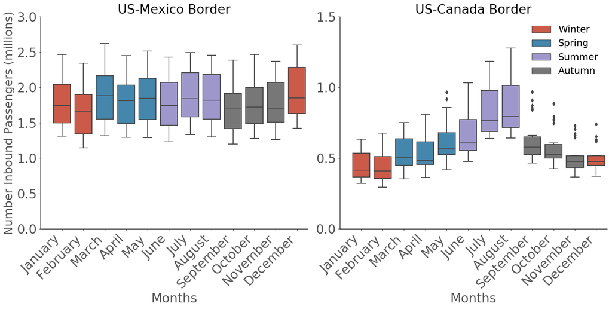

```python
Image(filename='boxPlot_PassengerSeosonalVariation.png')
```

### Border Influx Hotspots

The analysis of the border crossing data also provides a crucial insight into entry-ports with the maximum traffic. These entry-ports can be considered as the hotspots for the inbound traffic and can be used further by the federal agencies to allocate resources. For instance, I observed that the El Paso, Texas and San Ysidro, California carry the maximum load of traffic between US-Mexico border. Similarly, Buffalo-Niagara Falls, New York manages maximum border influx at the US-Canada border.

```python
%%HTML
<iframe width="100%" height="600" src="hotSpots_US_Map.html"></iframe>
```

[interactive chart not shown]